# Data

# Number of layers

```python
type(ruf["Layers"])
#ruf['Layers'][:]
ruf["nLayers"] = ruf["Layers"].apply(lambda x: x["Conv2D"])
```

```python
ruf
```

|  | Layers | filters | history | kernel_size | finalACC | nLayers |
| --- | --- | --- | --- | --- | --- | --- |
| 1 | {'Conv2D': 1, 'Dense': 1, 'Flatten': 1} | 15 | [0.87583333, 0.89, 0.89591664] | 22 | 0.895917 | 1 |
| 2 | {'Conv2D': 2, 'Dense': 2, 'Flatten': 1} | 15 | [0.8785833, 0.8918333, 0.8979167] | 22 | 0.897917 | 2 |
| 3 | {'Conv2D': 3, 'Dense': 3, 'Flatten': 1} | 15 | [0.87916666, 0.893, 0.898] | 22 | 0.898000 | 3 |
| 4 | {'Conv2D': 4, 'Dense': 4, 'Flatten': 1} | 15 | [0.86575, 0.88, 0.89433336] | 22 | 0.894333 | 4 |
| 5 | {'Conv2D': 1, 'Dense': 1, 'Flatten': 1} | 15 | [0.87091666, 0.88708335, 0.89475] | 23 | 0.894750 | 1 |
| ... | ... | ... | ... | ... | ... | ... |
| 212 | {'Conv2D': 4, 'Dense': 4, 'Flatten': 1} | 20 | [0.8509167, 0.88125, 0.89816666] | 43 | 0.898167 | 4 |
| 213 | {'Conv2D': 1, 'Dense': 1, 'Flatten': 1} | 20 | [0.8806667, 0.88441664, 0.8951667] | 44 | 0.895167 | 1 |
| 214 | {'Conv2D': 2, 'Dense': 2, 'Flatten': 1} | 20 | [0.8785833, 0.8925, 0.899] | 44 | 0.899000 | 2 |
| 215 | {'Conv2D': 3, 'Dense': 3, 'Flatten': 1} | 20 | [0.86558336, 0.8895, 0.89575] | 44 | 0.895750 | 3 |
| 216 | {'Conv2D': 4, 'Dense': 4, 'Flatten': 1} | 20 | [0.84033334, 0.8803333, 0.89525] | 44 | 0.895250 | 4 |

216 rows × 6 columns

```python
import matplotlib.pyplot as plt

plt.figure(figsize=(15,15))
fig = px.scatter_3d(ruf, x="nLayers",
                    y='kernel_size',
                    z='filters',
                    color="finalACC",
                    )

fig.show()
```

[interactive chart not shown]

What is interessant to observe :

1. we have better accuracy for small kernel_sizes. Tipically, the best results come from tuples (2,2) < (3,3). We could imagine, in a first analyses, that this is normal, as smaller kernel_sizes will have to read the intere image with smaller steps (will have more steps to cross all the rows and columns)
2. for bigger values it seems that we have to increase the number of filters (it is in accordance with the previous point .1) if we want to achieve the same accuracy
3. the number of layers in this case (in the way the model was built) doesn't have a strong positive correlation with accuracy. It is taked for granted that higher number of layers improve the model performance. And this is what we certainly would observe more clearly here if the number of layers were superior than only 4. But we can have good accuracy values here with fewer layers.
4. Basically, if we have small kernel sizes, it will be necessary less layers and filters for a given accuracy. Otherwhise, we can expect to increase the number of filters and layers. Anyway, I don't think that this relationship must be seen as linear and always true, as the complexity of tasks and images data can really differ and change the output. This is by the way what we can observe above

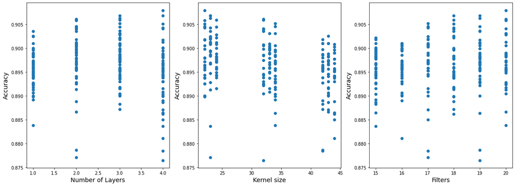

```python
#fig, (ax1,ax2,ax3) = plt.subplots(1,3,figsize=(10,10))
plt.figure(figsize=(20,7))

plt.subplot(1, 3, 1)
plt.scatter(ruf["nLayers"],ruf["finalACC"])
plt.xlabel("Number of Layers", fontsize=14)
plt.ylabel("Accuracy", fontsize=14)

plt.subplot(1, 3, 2)
plt.scatter(ruf["kernel_size"],ruf["finalACC"])
plt.xlabel("Kernel size", fontsize=14)
plt.ylabel("Accuracy", fontsize=14)

plt.subplot(1, 3, 3)
plt.scatter(ruf["filters"],ruf["finalACC"])
plt.xlabel("Filters", fontsize=14)


plt.ylabel("Accuracy", fontsize=14)
plt.show(fig)
```

Lets find and group the mean of the accuracy for each possible quantity of layers

```python
meanAcc = ruf.groupby(["nLayers"])["finalACC"].mean()
display(meanAcc)
meanFilters = ruf.groupby(["filters"])["finalACC"].mean()
meanFilters
```

```
nLayers
1    0.895704
2    0.897742
3    0.897753
4    0.894275
Name: finalACC, dtype: float64
```

```
filters
15    0.895384
16    0.895711
17    0.896535
18    0.896646
19    0.896477
20    0.897458
Name: finalACC, dtype: float64
```

```
Maximum mean accuracy  : 0.8980934233260665
```

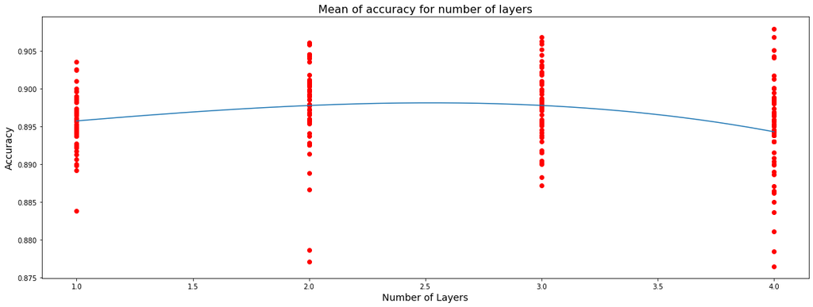

```python
from scipy.interpolate import make_interp_spline, BSpline
plt.figure(figsize=(20,7))
# 300 represents number of points to make between T.min and T.max
T = meanAcc.index
power = meanAcc

xnew = np.linspace(T.min(), T.max(), 300)

spl = make_interp_spline(T, power, k=3)  # type: BSpline
power_smooth = spl(xnew)

ymax = power_smooth.max()

print("Maximum mean accuracy  :", ymax)
plt.scatter(ruf["nLayers"],ruf["finalACC"],c="r")
plt.xlabel("Number of Layers", fontsize=14)
plt.ylabel("Accuracy", fontsize=14)
plt.title("Mean of accuracy for number of layers", fontsize=16)

plt.plot(xnew, power_smooth)
plt.show()
```

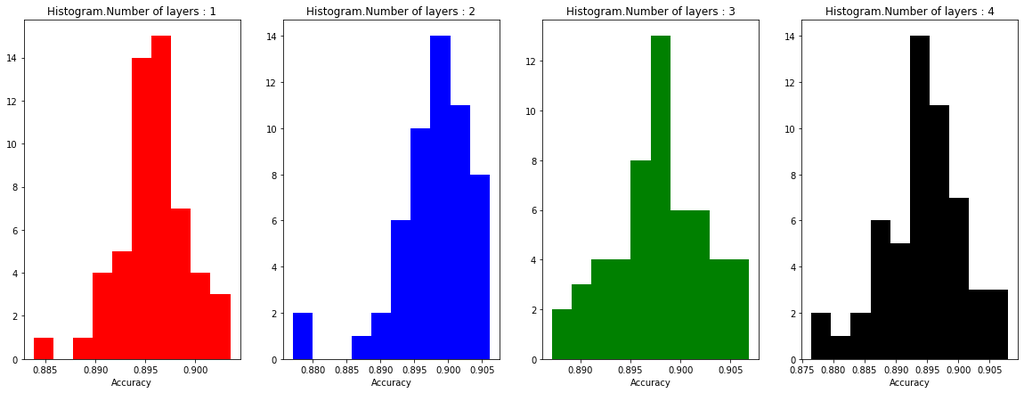

```python
color = ["r","b","g","k"]
fig,ax = plt.subplots(figsize=(20,7))
for i in range(1,5):

    lay = ruf.loc[ruf["nLayers"]==i]
    plt.subplot(1,4,i)
    plt.hist(lay["finalACC"],color=color[i-1])

    plt.title(f"Histogram.Number of layers : {i}")
    plt.xlabel("Accuracy")

ax.set_facecolor('#d8dcd6')
plt.show()
```

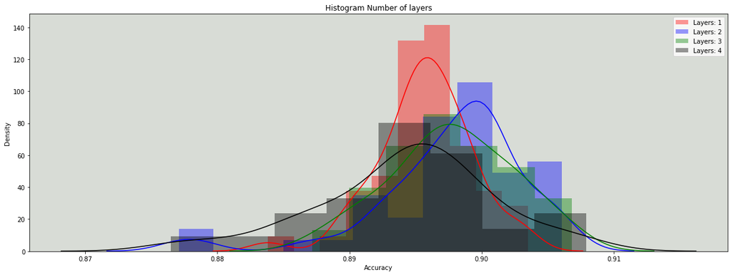

```python
#fig,ax = plt.subplots(2,2,figsize=(20,20))
import seaborn as sns
color = ["r","b","g","k"]
fig,ax = plt.subplots(figsize=(20,7))
for i in range(1,5):

    lay = ruf.loc[ruf["nLayers"]==i]
    sns.distplot(lay["finalACC"], kde=True, rug=False,color=color[i-1]);
    plt.title("Histogram Number of layers")
    plt.xlabel("Accuracy")
    ax.set_facecolor('#d8dcd6')
    plt.ylabel("Density")
plt.legend(['Layers: 1', 'Layers: 2', 'Layers: 3',"Layers: 4"])
plt.show()
    #lay4.head()
```

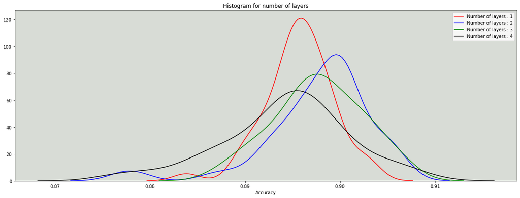

```python
import seaborn as sns

color = ["r","b","g","k"]
fig,ax = plt.subplots(figsize=(20,7))


for i in range(1,5):

    lay = ruf.loc[ruf["nLayers"]==i]

    sns.distplot(lay["finalACC"], kde=True, rug=False,hist=False,color=color[i-1],label=f"Number of layers : {i}");

    plt.title(f"Histogram for number of layers")
    plt.xlabel("Accuracy")
    ax.set_facecolor('#d8dcd6')

plt.show()
```

Conclusion: could we say that we have a threshold that no matter more layers we add we will end up at the same accuracy? If so, we can save computation with less layers.